# Investigate a Dataset: TMDb Movie Data

Dataset analyzed: TMDb Movies dataset

## Introduction

For this project, I used the TMDb movie dataset to look at a few patterns in movie performance and how those patterns change across time and genre. The dataset includes information such as popularity, adjusted budget and revenue, runtime, genres, vote averages, and release year.

One thing I noticed early on is that a lot of the budget and revenue entries are listed as zero. I did not treat those as movies that literally had no budget or revenue. Instead, I treated them as missing financial information so they would not distort the financial part of the analysis.

## Questions

1. How are adjusted budget, adjusted revenue, and popularity related for movies that have usable financial data?
2. How do popularity and runtime change across release decades and genres?

These questions let me compare individual variables first and then look at how several variables relate to one another.

```python
# Import the packages used throughout the analysis.
import numpy as np
import pandas as pd
import matplotlib.pyplot as plt

%matplotlib inline

# Load the TMDb dataset.
df = pd.read_csv('tmdb-movies.csv')

# Preview the data.
df.head()
```

|  | id | imdb_id | popularity | budget | revenue | original_title | cast | homepage | director | tagline | keywords | overview | runtime | genres | production_companies | release_date | vote_count | vote_average | release_year | budget_adj | revenue_adj |
| --- | --- | --- | --- | --- | --- | --- | --- | --- | --- | --- | --- | --- | --- | --- | --- | --- | --- | --- | --- | --- | --- |
| 0 | 135397 | tt0369610 | 32.985763 | 150000000 | 1513528810 | Jurassic World | Chris Pratt\|Bryce Dallas Howard\|Irrfan Khan\|Vi... | http://www.jurassicworld.com/ | Colin Trevorrow | The park is open. | monster\|dna\|tyrannosaurus rex\|velociraptor\|island | Twenty-two years after the events of Jurassic ... | 124 | Action\|Adventure\|Science Fiction\|Thriller | Universal Studios\|Amblin Entertainment\|Legenda... | 6/9/15 | 5562 | 6.5 | 2015 | 1.379999e+08 | 1.392446e+09 |
| 1 | 76341 | tt1392190 | 28.419936 | 150000000 | 378436354 | Mad Max: Fury Road | Tom Hardy\|Charlize Theron\|Hugh Keays-Byrne\|Nic... | http://www.madmaxmovie.com/ | George Miller | What a Lovely Day. | future\|chase\|post-apocalyptic\|dystopia\|australia | An apocalyptic story set in the furthest reach... | 120 | Action\|Adventure\|Science Fiction\|Thriller | Village Roadshow Pictures\|Kennedy Miller Produ... | 5/13/15 | 6185 | 7.1 | 2015 | 1.379999e+08 | 3.481613e+08 |
| 2 | 262500 | tt2908446 | 13.112507 | 110000000 | 295238201 | Insurgent | Shailene Woodley\|Theo James\|Kate Winslet\|Ansel... | http://www.thedivergentseries.movie/#insurgent | Robert Schwentke | One Choice Can Destroy You | based on novel\|revolution\|dystopia\|sequel\|dyst... | Beatrice Prior must confront her inner demons ... | 119 | Adventure\|Science Fiction\|Thriller | Summit Entertainment\|Mandeville Films\|Red Wago... | 3/18/15 | 2480 | 6.3 | 2015 | 1.012000e+08 | 2.716190e+08 |
| 3 | 140607 | tt2488496 | 11.173104 | 200000000 | 2068178225 | Star Wars: The Force Awakens | Harrison Ford\|Mark Hamill\|Carrie Fisher\|Adam D... | http://www.starwars.com/films/star-wars-episod... | J.J. Abrams | Every generation has a story. | android\|spaceship\|jedi\|space opera\|3d | Thirty years after defeating the Galactic Empi... | 136 | Action\|Adventure\|Science Fiction\|Fantasy | Lucasfilm\|Truenorth Productions\|Bad Robot | 12/15/15 | 5292 | 7.5 | 2015 | 1.839999e+08 | 1.902723e+09 |
| 4 | 168259 | tt2820852 | 9.335014 | 190000000 | 1506249360 | Furious 7 | Vin Diesel\|Paul Walker\|Jason Statham\|Michelle ... | http://www.furious7.com/ | James Wan | Vengeance Hits Home | car race\|speed\|revenge\|suspense\|car | Deckard Shaw seeks revenge against Dominic Tor... | 137 | Action\|Crime\|Thriller | Universal Pictures\|Original Film\|Media Rights ... | 4/1/15 | 2947 | 7.3 | 2015 | 1.747999e+08 | 1.385749e+09 |

## Data Wrangling

I started by checking the overall shape of the dataset, the column types, missing values, duplicate rows, and values that looked unusual. The biggest issue for this project was the number of zero values in `budget_adj` and `revenue_adj`.

I kept movies with missing financial information in the main cleaned dataset because they can still be useful when looking at popularity, genre, runtime, or release year. For the financial question, I made a separate subset that only includes movies with positive adjusted budget and adjusted revenue values.

```python
# Inspect the number of rows/columns and the data types.
print("Dataset shape:", df.shape)
df.info()
```

```
Dataset shape: (10866, 21)
<class 'pandas.core.frame.DataFrame'>
RangeIndex: 10866 entries, 0 to 10865
Data columns (total 21 columns):
 #   Column                Non-Null Count  Dtype
---  ------                --------------  -----
 0   id                    10866 non-null  int64
 1   imdb_id               10856 non-null  object
 2   popularity            10866 non-null  float64
 3   budget                10866 non-null  int64
 4   revenue               10866 non-null  int64
 5   original_title        10866 non-null  object
 6   cast                  10790 non-null  object
 7   homepage              2936 non-null   object
 8   director              10822 non-null  object
 9   tagline               8042 non-null   object
 10  keywords              9373 non-null   object
 11  overview              10862 non-null  object
 12  runtime               10866 non-null  int64
 13  genres                10843 non-null  object
 14  production_companies  9836 non-null   object
 15  release_date          10866 non-null  object
 16  vote_count            10866 non-null  int64
 17  vote_average          10866 non-null  float64
 18  release_year          10866 non-null  int64
 19  budget_adj            10866 non-null  float64
 20  revenue_adj           10866 non-null  float64
dtypes: float64(4), int64(6), object(11)
memory usage: 1.7+ MB
```

```python
# Check missing values, duplicate rows, and zero values in important numeric columns.
print("Duplicate rows:", df.duplicated().sum())

important_columns = [
    'budget_adj', 'revenue_adj', 'popularity', 'vote_average',
    'runtime', 'genres', 'release_year'
]

print("\nMissing values:")
print(df[important_columns].isnull().sum())

print("\nZero values:")
for column in ['budget_adj', 'revenue_adj', 'runtime']:
    print(f"{column}: {(df[column] == 0).sum()}")
```

```
Duplicate rows: 1

Missing values:
budget_adj       0
revenue_adj      0
popularity       0
vote_average     0
runtime          0
genres          23
release_year     0
dtype: int64

Zero values:
budget_adj: 5696
revenue_adj: 6016
runtime: 31
```

### Cleaning decisions

I made a few cleaning choices before starting the analysis:

- Removed exact duplicate rows.
- Removed rows with missing genre values because genre is used in the second question.
- Removed rows where runtime is zero because a zero-minute movie is not useful for this analysis.
- Kept the larger cleaned dataset for the non-financial comparisons.
- Created a separate `financial_df` with movies that have positive adjusted budget and adjusted revenue values.
- Added adjusted profit using `revenue_adj - budget_adj`. I only use this as a simple descriptive measure because the dataset does not include every possible cost tied to a movie.

```python
# Create the main cleaned dataset.
clean_df = df.drop_duplicates().copy()
clean_df = clean_df.dropna(subset=['genres'])
clean_df = clean_df[clean_df['runtime'] > 0].copy()

# Create a financial subset only where both adjusted budget and revenue are reported.
financial_df = clean_df[
    (clean_df['budget_adj'] > 0) &
    (clean_df['revenue_adj'] > 0)
].copy()

# Create an adjusted profit variable for descriptive comparisons.
financial_df['profit_adj'] = (
    financial_df['revenue_adj'] - financial_df['budget_adj']
)

print("Rows in original dataset:", len(df))
print("Rows in cleaned dataset:", len(clean_df))
print("Rows with usable financial data:", len(financial_df))
```

```
Rows in original dataset: 10866
Rows in cleaned dataset: 10812
Rows with usable financial data: 3854
```

### Reusable plotting function

I used a small plotting function to keep the chart formatting consistent. It adds the title and axis labels, and I call it more than once throughout the analysis.

```python
def label_plot(title, xlabel, ylabel):
    """Add a title and axis labels to the current Matplotlib plot."""
    plt.title(title)
    plt.xlabel(xlabel)
    plt.ylabel(ylabel)
    plt.tight_layout()
```

## Exploratory Data Analysis

### Question 1: How are adjusted budget, adjusted revenue, and popularity related?

I started by looking at the variables on their own before comparing them. The financial values are very right-skewed, so the median is useful to look at along with the mean.

```python
# Summary statistics for the financial variables and popularity.
financial_summary = financial_df[
    ['budget_adj', 'revenue_adj', 'profit_adj', 'popularity', 'vote_average']
].describe()

financial_summary
```

|  | budget_adj | revenue_adj | profit_adj | popularity | vote_average |
| --- | --- | --- | --- | --- | --- |
| count | 3.854000e+03 | 3.854000e+03 | 3.854000e+03 | 3854.000000 | 3854.000000 |
| mean | 4.423999e+07 | 1.370647e+08 | 9.282470e+07 | 1.191554 | 6.168163 |
| std | 4.480925e+07 | 2.161114e+08 | 1.940715e+08 | 1.475162 | 0.794920 |
| min | 9.693980e-01 | 2.370705e+00 | -4.139124e+08 | 0.001117 | 2.200000 |
| 25% | 1.309053e+07 | 1.835735e+07 | -1.504995e+06 | 0.462367 | 5.700000 |
| 50% | 3.001611e+07 | 6.173068e+07 | 2.737064e+07 | 0.797511 | 6.200000 |
| 75% | 6.061307e+07 | 1.632577e+08 | 1.074548e+08 | 1.368324 | 6.700000 |
| max | 4.250000e+08 | 2.827124e+09 | 2.750137e+09 | 32.985763 | 8.400000 |

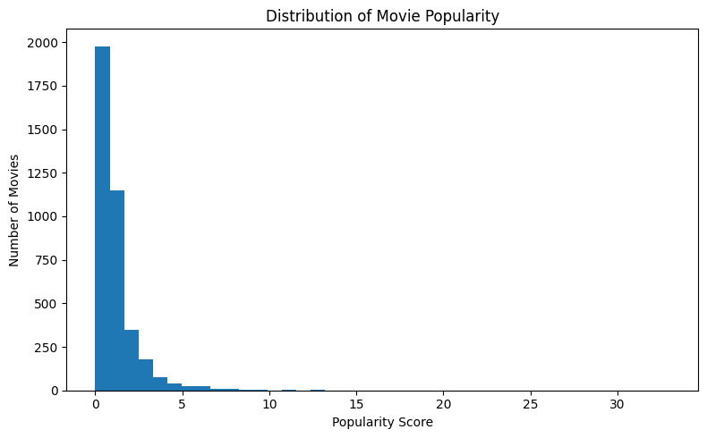

```python
# 1D exploration: distribution of movie popularity.
plt.figure(figsize=(8, 5))
plt.hist(financial_df['popularity'], bins=40)
label_plot(
    'Distribution of Movie Popularity',
    'Popularity Score',
    'Number of Movies'
)
plt.show()
```

Most movies are grouped toward the lower end of the popularity scale, while a smaller number have much higher popularity values. That makes the distribution right-skewed and means a few highly popular movies can pull the average upward.

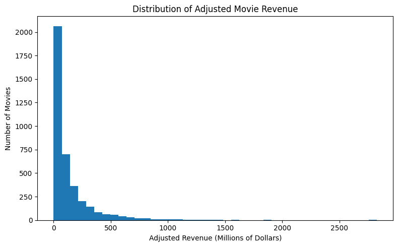

```python
# 1D exploration: distribution of adjusted revenue.
# The x-axis is shown in millions of inflation-adjusted dollars for readability.
plt.figure(figsize=(8, 5))
plt.hist(financial_df['revenue_adj'] / 1_000_000, bins=40)
label_plot(
    'Distribution of Adjusted Movie Revenue',
    'Adjusted Revenue (Millions of Dollars)',
    'Number of Movies'
)
plt.show()
```

Adjusted revenue has a similar shape. Most movies fall toward the lower end, while a much smaller group of very successful movies reaches extremely high revenue values.

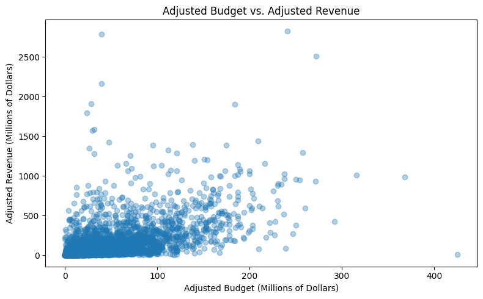

```
Pearson correlation: 0.570
```

```python
# 2D exploration: adjusted budget versus adjusted revenue.
plt.figure(figsize=(8, 5))
plt.scatter(
    financial_df['budget_adj'] / 1_000_000,
    financial_df['revenue_adj'] / 1_000_000,
    alpha=0.35
)
label_plot(
    'Adjusted Budget vs. Adjusted Revenue',
    'Adjusted Budget (Millions of Dollars)',
    'Adjusted Revenue (Millions of Dollars)'
)
plt.show()

budget_revenue_corr = financial_df['budget_adj'].corr(financial_df['revenue_adj'])
print(f"Pearson correlation: {budget_revenue_corr:.3f}")
```

The scatterplot shows a clear positive relationship between adjusted budget and adjusted revenue, but the points are still spread out quite a bit. Movies with larger budgets often make more revenue, although budget by itself does not explain the outcome.

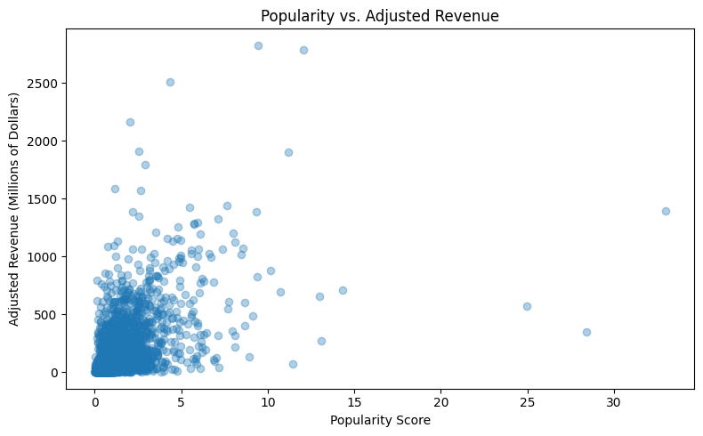

```
Pearson correlation: 0.547
```

```python
# 2D exploration: popularity versus adjusted revenue.
plt.figure(figsize=(8, 5))
plt.scatter(
    financial_df['popularity'],
    financial_df['revenue_adj'] / 1_000_000,
    alpha=0.35
)
label_plot(
    'Popularity vs. Adjusted Revenue',
    'Popularity Score',
    'Adjusted Revenue (Millions of Dollars)'
)
plt.show()

pop_revenue_corr = financial_df['popularity'].corr(financial_df['revenue_adj'])
print(f"Pearson correlation: {pop_revenue_corr:.3f}")
```

Popularity also has a positive relationship with adjusted revenue. Movies with higher popularity often have higher revenue, but there are plenty of exceptions, so popularity does not explain financial performance on its own.

```python
# Compare several numeric variables at once with a correlation matrix.
correlations = financial_df[
    ['budget_adj', 'revenue_adj', 'popularity', 'vote_average']
].corr()

correlations.round(3)
```

|  | budget_adj | revenue_adj | popularity | vote_average |
| --- | --- | --- | --- | --- |
| budget_adj | 1.000 | 0.570 | 0.399 | 0.037 |
| revenue_adj | 0.570 | 1.000 | 0.547 | 0.267 |
| popularity | 0.399 | 0.547 | 1.000 | 0.318 |
| vote_average | 0.037 | 0.267 | 0.318 | 1.000 |

The correlation values support what the scatterplots show. Adjusted revenue has positive relationships with both adjusted budget and popularity. Vote average is less strongly related to the financial variables. These are correlations, so they do not show that one variable directly causes another.

### Question 2: How do movie popularity and runtime vary across release decades and genres?

For this question, I went back to the broader cleaned dataset because budget and revenue are not required. I grouped release years into decades and compared movie counts, popularity, vote averages, and runtime over time.

Before grouping movies by decade and genre, I looked at runtime on its own. This gives me a baseline for the typical spread of movie lengths before comparing groups.

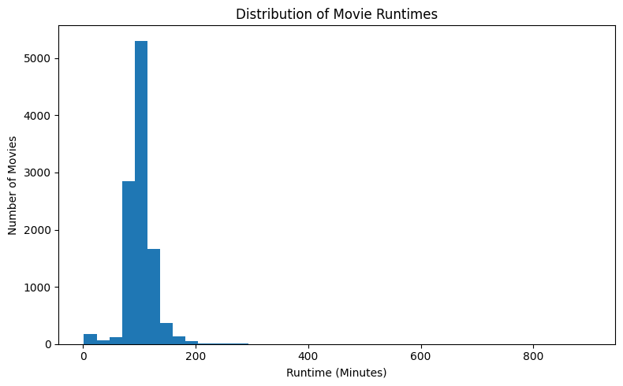

```python
# 1D exploration for Question 2: distribution of movie runtimes.
plt.figure(figsize=(8, 5))
plt.hist(clean_df['runtime'], bins=40)
label_plot(
    'Distribution of Movie Runtimes',
    'Runtime (Minutes)',
    'Number of Movies'
)
plt.show()
```

Most movies are concentrated around typical feature-length runtimes, while a smaller number are much shorter or longer. Because the distribution has some extreme values, I use the median when comparing runtime across decades and genres.

```python
# Create a decade variable.
clean_df['decade'] = np.floor(clean_df['release_year'] / 10).astype(int) * 10

decade_summary = clean_df.groupby('decade').agg(
    movie_count=('id', 'size'),
    mean_popularity=('popularity', 'mean'),
    mean_vote=('vote_average', 'mean'),
    median_runtime=('runtime', 'median')
)

decade_summary
```

| decade | movie_count | mean_popularity | mean_vote | median_runtime |
| --- | --- | --- | --- | --- |
| 1960 | 362 | 0.424244 | 6.246133 | 109.0 |
| 1970 | 506 | 0.485495 | 6.376680 | 105.0 |
| 1980 | 1062 | 0.524726 | 6.080132 | 101.0 |
| 1990 | 1763 | 0.621460 | 5.998469 | 102.0 |
| 2000 | 3547 | 0.633965 | 5.920412 | 98.0 |
| 2010 | 3572 | 0.759594 | 5.903135 | 95.0 |

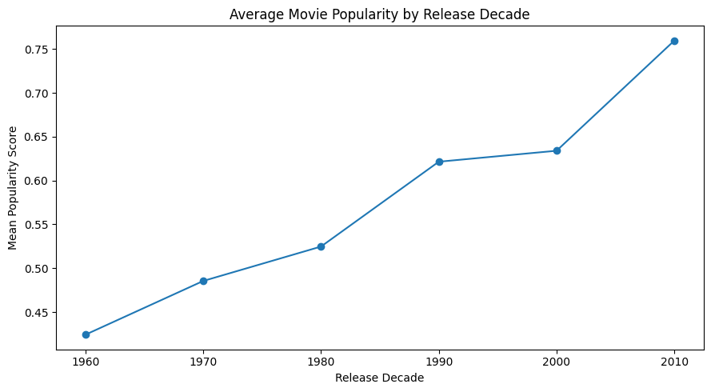

```python
# 2D exploration: average popularity across decades.
plt.figure(figsize=(9, 5))
plt.plot(
    decade_summary.index,
    decade_summary['mean_popularity'],
    marker='o'
)
label_plot(
    'Average Movie Popularity by Release Decade',
    'Release Decade',
    'Mean Popularity Score'
)
plt.show()
```

Average popularity is higher in the more recent decades in this dataset. I would be careful about reading too much into that by itself because TMDb popularity is based on activity on the platform, and older movies may not receive the same kind of attention or coverage as newer releases.

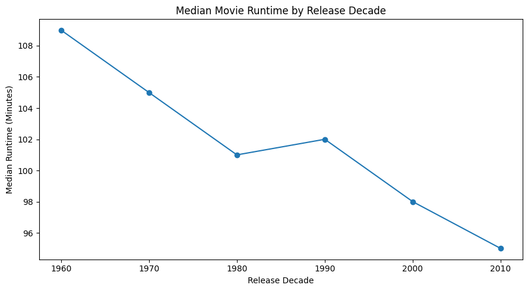

```python
# 2D exploration: median runtime across decades.
plt.figure(figsize=(9, 5))
plt.plot(
    decade_summary.index,
    decade_summary['median_runtime'],
    marker='o'
)
label_plot(
    'Median Movie Runtime by Release Decade',
    'Release Decade',
    'Median Runtime (Minutes)'
)
plt.show()
```

Median runtime also changes across decades. It does not follow the exact same pattern as popularity, so the two trends are better treated as separate characteristics instead of assuming one explains the other.

```python
# Split multi-genre strings so each movie can contribute to each listed genre.
genre_df = clean_df.assign(
    genre=clean_df['genres'].str.split('|')
).explode('genre')

genre_summary = genre_df.groupby('genre').agg(
    movie_count=('id', 'size'),
    mean_popularity=('popularity', 'mean'),
    mean_vote=('vote_average', 'mean'),
    median_runtime=('runtime', 'median')
).sort_values('movie_count', ascending=False)

genre_summary.head(10)
```

| genre | movie_count | mean_popularity | mean_vote | median_runtime |
| --- | --- | --- | --- | --- |
| Drama | 4751 | 0.592374 | 6.165839 | 106.0 |
| Comedy | 3782 | 0.593997 | 5.905579 | 96.0 |
| Thriller | 2905 | 0.741917 | 5.751979 | 100.0 |
| Action | 2382 | 0.926235 | 5.787951 | 101.0 |
| Romance | 1705 | 0.594030 | 6.045044 | 104.0 |
| Horror | 1629 | 0.466995 | 5.340270 | 92.0 |
| Adventure | 1470 | 1.153768 | 5.940952 | 101.0 |
| Crime | 1353 | 0.745410 | 6.125351 | 104.0 |
| Family | 1229 | 0.787579 | 5.999186 | 91.0 |
| Science Fiction | 1228 | 1.002023 | 5.666694 | 96.0 |

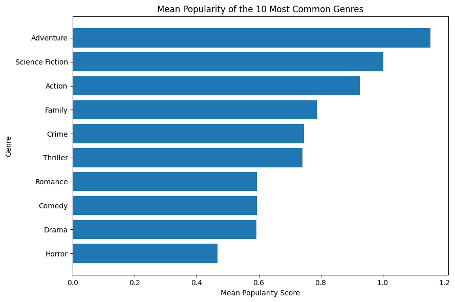

```python
# Compare popularity among the 10 most common genres.
top_genres = genre_summary.head(10).sort_values('mean_popularity')

plt.figure(figsize=(9, 6))
plt.barh(top_genres.index, top_genres['mean_popularity'])
label_plot(
    'Mean Popularity of the 10 Most Common Genres',
    'Mean Popularity Score',
    'Genre'
)
plt.show()
```

The most common genres do not all have the same average popularity. Adventure, Science Fiction, and Action are among the genres with higher averages in this dataset. A genre appearing more often does not automatically mean that it has higher popularity.

```python
# Additional multi-variable comparison:
# financial performance by genre, limited to genres with at least 100 movies
# containing usable budget and revenue data.
financial_genres = financial_df.assign(
    genre=financial_df['genres'].str.split('|')
).explode('genre')

genre_financial_summary = financial_genres.groupby('genre').agg(
    movie_count=('id', 'size'),
    median_profit_adj=('profit_adj', 'median'),
    median_revenue_adj=('revenue_adj', 'median'),
    mean_popularity=('popularity', 'mean')
)

genre_financial_summary = genre_financial_summary[
    genre_financial_summary['movie_count'] >= 100
].sort_values('median_profit_adj', ascending=False)

genre_financial_summary.head(10)
```

| genre | movie_count | median_profit_adj | median_revenue_adj | mean_popularity |
| --- | --- | --- | --- | --- |
| Animation | 201 | 1.215841e+08 | 2.057296e+08 | 1.710622 |
| Adventure | 749 | 7.032041e+07 | 1.445834e+08 | 1.867693 |
| Family | 425 | 6.735360e+07 | 1.306618e+08 | 1.459043 |
| Fantasy | 396 | 6.356663e+07 | 1.193492e+08 | 1.754315 |
| Action | 1085 | 4.333838e+07 | 9.488289e+07 | 1.567116 |
| War | 119 | 4.261116e+07 | 8.990674e+07 | 1.246129 |
| Science Fiction | 519 | 3.434549e+07 | 8.361457e+07 | 1.873294 |
| Comedy | 1358 | 2.852542e+07 | 6.187164e+07 | 1.012321 |
| Horror | 463 | 2.428378e+07 | 4.137782e+07 | 0.854005 |
| Thriller | 1204 | 2.392176e+07 | 6.042219e+07 | 1.258950 |

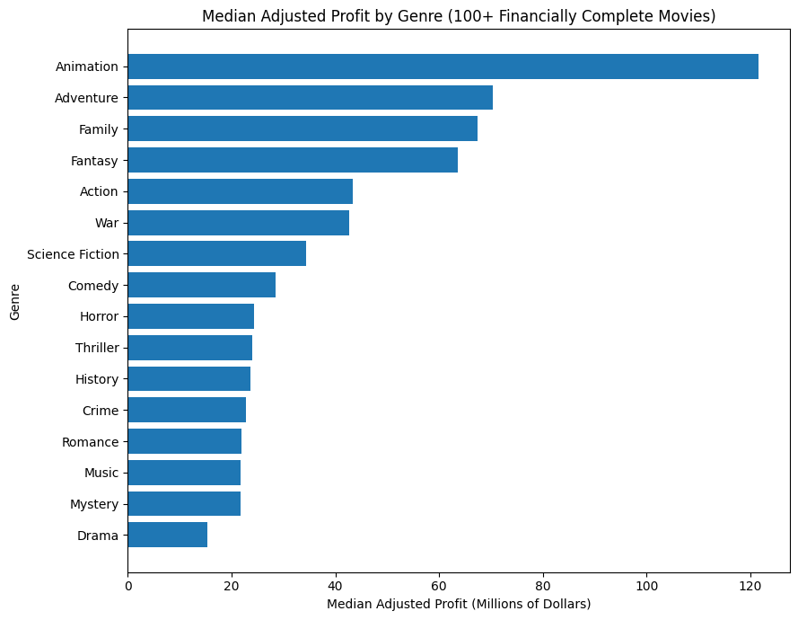

```python
# Visualize median adjusted profit for genres with at least 100
# financially complete movies.
plot_genres = genre_financial_summary.sort_values('median_profit_adj')

plt.figure(figsize=(9, 7))
plt.barh(
    plot_genres.index,
    plot_genres['median_profit_adj'] / 1_000_000
)
label_plot(
    'Median Adjusted Profit by Genre (100+ Financially Complete Movies)',
    'Median Adjusted Profit (Millions of Dollars)',
    'Genre'
)
plt.show()
```

Looking at median adjusted profit by genre adds another comparison to the financial side of the project. Some genres have higher median values than others among movies with usable financial data. Since a movie can belong to more than one genre, the genre groups overlap and should not be treated as completely separate groups.

## Conclusions

### Main findings

For the first question, movies with usable financial information show a moderate positive relationship between adjusted budget and adjusted revenue. The Pearson correlation in the cleaned financial subset is about 0.57. Popularity and adjusted revenue are also positively related, with a correlation of about 0.55. The relationships are noticeable, but the scatterplots also show a lot of variation. In other words, bigger budgets and higher popularity are often connected with higher revenue in this dataset, but neither one guarantees it.

For the second question, popularity and runtime both change across time and genre. Mean popularity is higher in the more recent decades, while median runtime is lower in the 2010s than in some earlier decades. Among the most common genres, Adventure, Science Fiction, and Action have relatively high mean popularity values. The genre comparison for adjusted profit also shows that financial results vary across genres for movies with reported budget and revenue data.

### Limitations

There are a few limits to keep in mind when reading these results:

1. Missing financial information: More than half of the original records have zero adjusted budget or adjusted revenue values. I treated those as missing, so the financial analysis only represents the movies with usable values.
2. Popularity comes from TMDb: The popularity score is specific to the TMDb platform and should not be treated as a perfect measure of general audience interest.
3. Genres overlap: A movie can have more than one genre, so the same movie can appear in several genre groups after the genre column is split.
4. This is observational data: The patterns in this project are correlations. They do not prove that budget, popularity, or genre directly causes a movie to earn more revenue.
5. Other factors are missing: Marketing, release strategy, competition, franchise status, and other outside factors can affect revenue and popularity but are not fully represented in this dataset.

### Further research

If I continued this project, I would look at whether the budget and revenue relationship changes by decade. It could also be useful to compare return on investment while being careful with unusually small reported budgets, or to build a model that considers release year, genre, and popularity at the same time.